# Campagne de recrutement synchornisée des enseignants-chercheurs

Julien Gossa

25/02/2020

## Information globales

La campagne d’emplois synchronisée de recrutement des enseignants-chercheurs (EC) est la procédure principale de recrutement des EC titulaires.

Les données sont les suivantes :

- [Galaxy](https://www.galaxie.enseignementsup-recherche.gouv.fr/ensup/ListesPostesPublies/Emplois_publies_TrieParCorps.html)
- [DataESR](https://data.enseignementsup-recherche.gouv.fr/explore/dataset/fr-esr-enseignants-titulaires-esr-public/information/) (seule la dernière année 2017-2018 est utilisée pour les effectifs de référence)

Des versions exploitables sont disponibles ici :

- Campagne 2018
- Campagne 2019
- Campagne 2020 (mise à jour le 26/02/2020 à 16h)
- Campagne 2021 (mise à jour le 25/02/2021 à 11h)
- Campagnes 2018-2021
- Effectifs 2018-201-
- Campagne CNU
- Campagne Etablissements

### Nombre d’emplois

Les enseignants-chercheurs titulaires sont divisés en deux corps :

- MCF : Maitres de conférences, qui représente le premier poste titulaire ;
- PR : Professeur des universités.

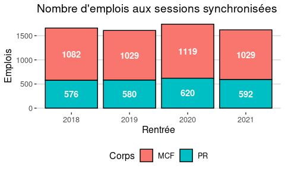

### Renouvellement

Le renouvellement est défini comme le rapport entre le nombre d’emplois de Maîtres de conférences et les effectifs d’enseignants-chercheurs :

renouvellement = emplois_MCF / (effectifs_MCF + effectifs_PR)

Le renouvellement peut se lire en pourcents ou en année. Par exemple, un renouvellement de 0.05 peut se lire : « 5% des effectifs sont renouvelés » ou « Au rythme actuel, il faudra 20 ans pour renouveler les effectifs ».

*Attention* : cette lecture suppose un effectif constant (hypothèse solide à l’heure actuelle). Si on considère une absence de départs (notamment à la retraite), la lecture devient « les effectifs seront augmenté de 5% » ou « Au rythme actuel, il faudra 20 ans pour doubler les effectifs ». La vérité est entre les deux.

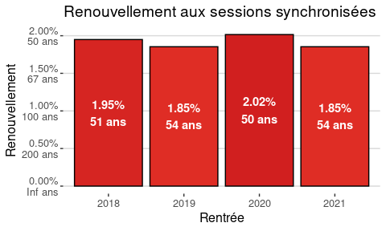

### Promotion

La promotion est définie comme le rapport entre le nombre d’emplois de Professeurs et les effectifs Maîtres de conférences :

promotion = emplois_PR / effectifs_MCF

La promotion peut se lire en pourcents ou en année. Par exemple, une promotion de 0.05 peut se lire : « 5% des MCF vont obtenir une promotion PR » ou « Au rythme actuel, il faudra 20 ans pour promouvoir tous les MCF ».

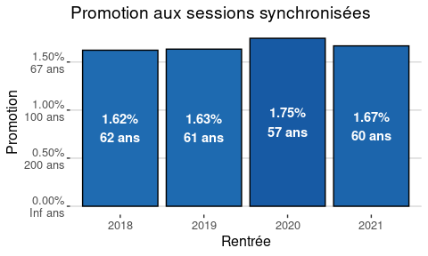

## Section CNU

*Attention* : Ces résultats ne tiennent pas compte des 169 postes sur plusieurs sections. Seule la première est prise en compte.

### Nombre d’emplois

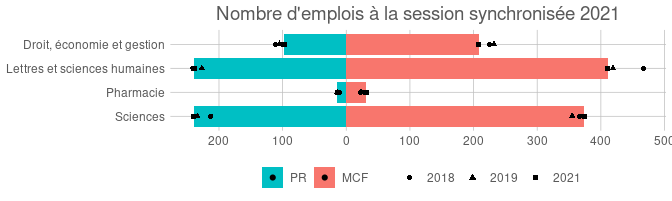

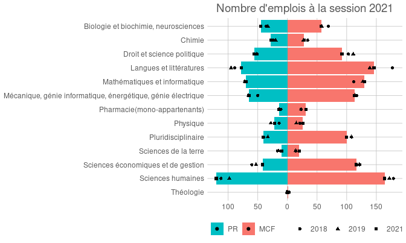

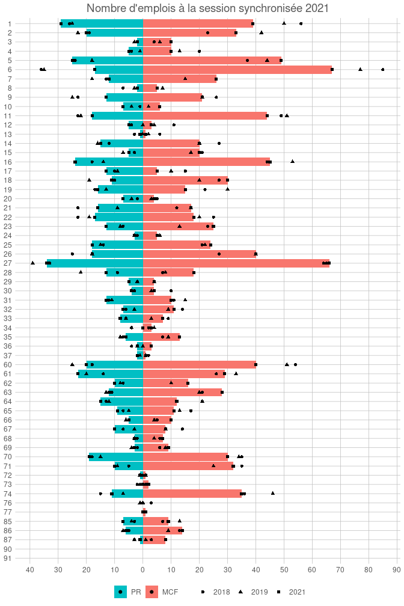

### Renouvellement

*Attention* : Les données 2018 et 2019 de la section 76 (Théologie Catholique) ont été filtrée pour améliorer la présentation des données (elle présente un renouvellement de 10% en 2018, mais sur un effectif non significatif)

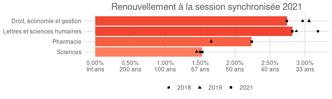

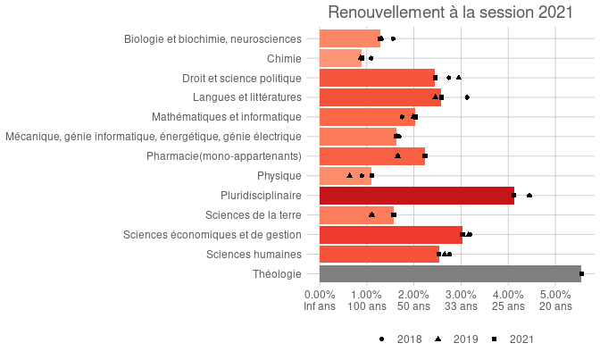

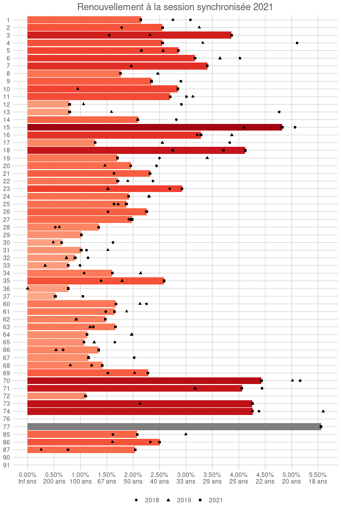

### Promotion

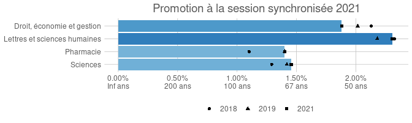

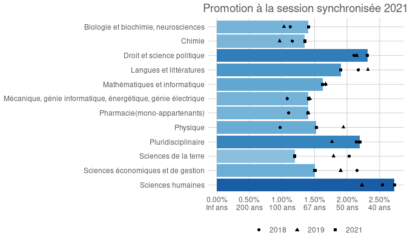

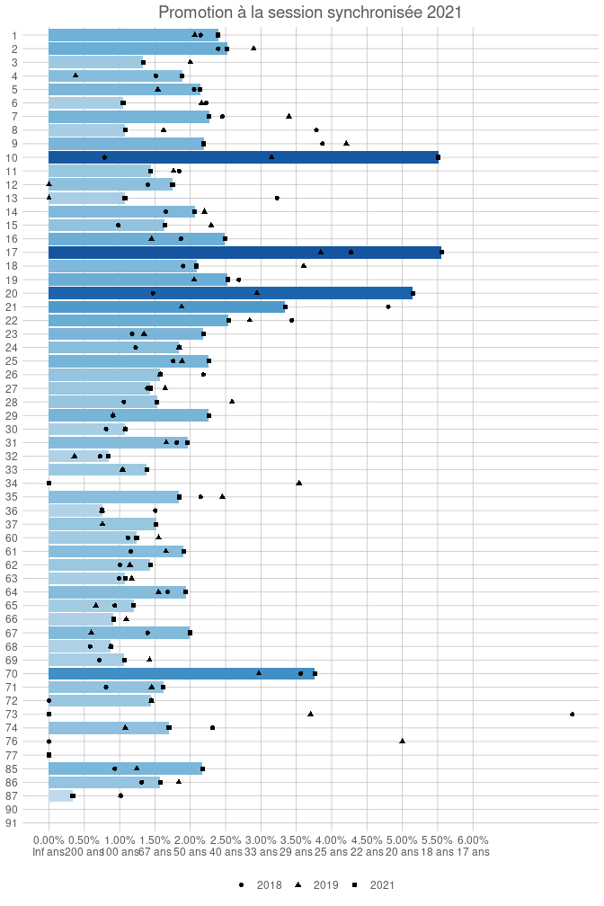

### Tableau

[output not shown]